[figure not shown]

Proprietary content. © Great Learning. All Rights Reserved. Unauthorized use or distribution prohibited.

# Face Mask Prediction using U-Net

Task is to predict the mask around the face in a given image.

# Instructions

- Some part of the code is already done for you
- You need to execute all the cells
- You need to add the code where ever you see `"#### Add your code here ####"`
- Marks are mentioned along with the cells

## Dataset

Faces in images marked with bounding boxes. Have around 409 images with around 1000 faces manually tagged via bounding box.

- Data file name: images.npy

### Mount Google drive if you are using google colab

- We recommend using Google Colab as you can face memory issues and longer runtimes while running on local

```python
#### Add your code here ####

from google.colab import drive
drive.mount('/content/drive/')
```

```python
# importing libraries

import tensorflow
tensorflow.__version__
```

```
'2.3.0'
```

```python
# import packages

import matplotlib.pyplot as plt
from matplotlib import pyplot
```

### Load the "images.npy" file (2 marks)

- This file contains images with details of bounding boxes

```python
import numpy as np
#data = #### Add your code here ####
project_path = ('/content/drive/My Drive/Colab_Notebooks/')

data = np.load( project_path + 'images.npy', allow_pickle=True)
```

### Check one sample from the loaded "images.npy" file (3 marks)

- Hint: print data[10][1]

```python
#### Add your code here ####

data[1][1]
```

```
[{'imageHeight': 697,
  'imageWidth': 1280,
  'label': ['Face'],
  'notes': '',
  'points': [{'x': 0.7053087757313109, 'y': 0.23260437375745527},
   {'x': 0.7692307692307693, 'y': 0.36182902584493043}]}]
```

[figure not shown]

```python
fig = plt.figure(figsize = (15, 7))
ax = fig.add_subplot(1, 1, 1)
plt.axis('off')
plt.imshow(data[408][0])
plt.show()
```

### Set image dimensions (2 marks)

- Initialize image height, image width with value: 224

```python
#### Add your code here ####

IMAGE_HEIGHT = 224
IMAGE_WIDTH = 224
IMAGE_SIZE = 224
```

### Create features and labels

- Here feature is the image
- The label is the mask
- Images will be stored in "X" array
- Masks will be stored in "masks" array

```python
import cv2
from tensorflow.keras.applications.mobilenet import preprocess_input

masks = np.zeros((int(data.shape[0]), IMAGE_HEIGHT, IMAGE_WIDTH))
X = np.zeros((int(data.shape[0]), IMAGE_HEIGHT, IMAGE_WIDTH, 3))
for index in range(data.shape[0]):
    img = data[index][0]
    img = cv2.resize(img, dsize=(IMAGE_HEIGHT, IMAGE_WIDTH), interpolation=cv2.INTER_CUBIC)
    try:
      img = img[:, :, :3]
    except:
      continue
    X[index] = preprocess_input(np.array(img, dtype=np.float32))
    for i in data[index][1]:
        x1 = int(i["points"][0]['x'] * IMAGE_WIDTH)
        x2 = int(i["points"][1]['x'] * IMAGE_WIDTH)
        y1 = int(i["points"][0]['y'] * IMAGE_HEIGHT)
        y2 = int(i["points"][1]['y'] * IMAGE_HEIGHT)
        masks[index][y1:y2, x1:x2] = 1
```

### Split the data into training and testing (3 marks)

- 400 images in training
- 9 images in testing data

```python
from sklearn.model_selection import train_test_split

X_train, X_test, y_train, y_test = train_test_split(X, masks, test_size=0.02, random_state=25)

print (X_train.shape)
print (X_test.shape)
```

```
(400, 224, 224, 3)
(9, 224, 224, 3)
```

Testing data

### Print a sample training image, image array and its mask (3 marks)

Print the image and image array

```
Clipping input data to the valid range for imshow with RGB data ([0..1] for floats or [0..255] for integers).
```

[figure not shown]

```python
#### Add your code here ####

# printing the image
plt.imshow(X_train[399])
```

```python
# printing the array
X_train[399]
```

```
array([[[-0.24705881, -0.41960782, -0.52156866],
        [-0.24705881, -0.40392154, -0.50588238],
        [-0.23921567, -0.38039213, -0.49019605],
        ...,
        [-0.35686272, -0.49803919, -0.60784316],
        [-0.34901959, -0.49019605, -0.60000002],
        [-0.30196077, -0.44313723, -0.5529412 ]],

       [[-0.21568626, -0.38823527, -0.49019605],
        [-0.23137254, -0.39607841, -0.49803919],
        [-0.18431371, -0.32549018, -0.43529409],
        ...,
        [-0.25490195, -0.39607841, -0.50588238],
        [-0.24705881, -0.38823527, -0.49803919],
        [-0.19215685, -0.33333331, -0.44313723]],

       [[-0.23137254, -0.40392154, -0.50588238],
        [-0.21568626, -0.372549  , -0.48235291],
        [-0.25490195, -0.39607841, -0.50588238],
        ...,
        [-0.24705881, -0.38823527, -0.49803919],
        [-0.20784312, -0.34901959, -0.4588235 ],
        [-0.23137254, -0.372549  , -0.48235291]],

       ...,

       [[-0.94509804, -0.95294118, -0.96862745],
        [-0.9137255 , -0.9137255 , -0.9137255 ],
        [-0.92941177, -0.92156863, -0.90588236],
        ...,
        [-0.97647059, -0.97647059, -0.97647059],
        [-0.97647059, -0.97647059, -0.97647059],
        [-0.97647059, -0.97647059, -0.97647059]],

       [[-0.96862745, -0.97647059, -0.99215686],
        [-0.96862745, -0.96862745, -0.96862745],
        [-0.97647059, -0.96862745, -0.95294118],
        ...,
        [-0.97647059, -0.97647059, -0.97647059],
        [-0.97647059, -0.97647059, -0.97647059],
        [-0.97647059, -0.97647059, -0.97647059]],

       [[-0.98431373, -0.98431373, -0.98431373],
        [-0.99215686, -0.99215686, -0.99215686],
        [-1.        , -1.        , -1.        ],
        ...,
        [-0.98431373, -0.98431373, -0.98431373],
        [-0.98431373, -0.98431373, -0.98431373],
        [-0.98431373, -0.98431373, -0.98431373]]])
```

Print the mask

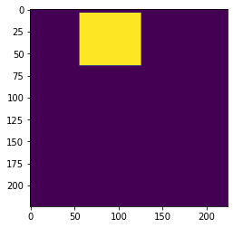

```python
#### Add your code here ####

#printing the mask
y_train[399]
plt.imshow(y_train[399])
```

## Create the model (7 marks)

- Add MobileNet as model with below parameter values
  - input_shape: IMAGE_HEIGHT, IMAGE_WIDTH, 3
  - include_top: False
  - alpha: 1.0
  - weights: "imagenet"
- Add UNET architecture layers
  - This is the trickiest part of the project, you need to research and implement it correctly

```python
from tensorflow.keras.applications.mobilenet import MobileNet
from tensorflow.keras.layers import Input, Reshape, UpSampling2D, Concatenate, Conv2D, BatchNormalization, Activation, SpatialDropout2D
from tensorflow.keras.models import Model


def conv_block_simple(prevlayer, filters, prefix, strides=(1, 1)):
    conv = Conv2D(filters, (3, 3), padding = 'same', kernel_initializer = 'he_normal', strides = strides, name = prefix + '_conv')(prevlayer)
    conv = BatchNormalization(name = prefix + 'BatchNormalization')(conv)
    conv = Activation('relu', name = prefix + 'ActivationLayer')(conv)
    return conv


def create_model(trainable=True):
    model = MobileNet(input_shape=(IMAGE_HEIGHT, IMAGE_WIDTH, 3), include_top=False, alpha=1.0, weights="imagenet")

    for layer in model.layers:
        layer.trainable = trainable

    #### Add your code here ####
    block1 = model.get_layer('conv_pw_13_relu').output
    block2 = model.get_layer('conv_pw_11_relu').output
    block3 = model.get_layer('conv_pw_5_relu').output
    block4 = model.get_layer('conv_pw_3_relu').output
    block5 = model.get_layer('conv_pw_1_relu').output

    up1 = Concatenate()([UpSampling2D()(block1), block2])
    conv6 = conv_block_simple(up1, 256, 'Conv_6_1')
    conv6 = conv_block_simple(conv6, 256, 'Conv_6_2')

    up2 = Concatenate()([UpSampling2D()(conv6), block3])
    conv7 = conv_block_simple(up2, 256, 'Conv_7_1')
    conv7 = conv_block_simple(conv7, 256, 'Conv_7_2')

    up3 = Concatenate()([UpSampling2D()(conv7), block4])
    conv8 = conv_block_simple(up3, 192, 'Conv_8_1')
    conv8 = conv_block_simple(conv8, 128, 'Conv_8_2')

    up4 = Concatenate()([UpSampling2D()(conv8), block5])
    conv9 = conv_block_simple(up4, 96, 'Conv_9_1')
    conv9 = conv_block_simple(conv9, 64, 'Conv_9_2')

    up5 = Concatenate()([UpSampling2D()(conv9), model.input])
    conv10 = conv_block_simple(up5, 48, 'Conv_10_1')
    conv10 = conv_block_simple(conv10, 32, 'Conv_10_2')
    conv10 = SpatialDropout2D(0.2)(conv10)

    x = Conv2D(1, (1, 1), activation = 'sigmoid')(conv10)
    x = Reshape((IMAGE_SIZE, IMAGE_SIZE))(x)
    return Model(inputs = model.input, outputs = x)
```

### Call the create_model function (2 marks)

- Give trainable=False as argument, if you want to freeze lower layers for fast training (but low accuracy)

```python
#### Add your code here ####

# Build model
model = create_model(True)
```

### Print model summary (2 marks)

```python
#### Add your code here ####

# Model Summary
model.summary()
```

```
Model: "functional_5"
__________________________________________________________________________________________________
Layer (type)                    Output Shape         Param #     Connected to
==================================================================================================
input_7 (InputLayer)            [(None, 224, 224, 3) 0
__________________________________________________________________________________________________
conv1_pad (ZeroPadding2D)       (None, 225, 225, 3)  0           input_7[0][0]
__________________________________________________________________________________________________
conv1 (Conv2D)                  (None, 112, 112, 32) 864         conv1_pad[0][0]
__________________________________________________________________________________________________
conv1_bn (BatchNormalization)   (None, 112, 112, 32) 128         conv1[0][0]
__________________________________________________________________________________________________
conv1_relu (ReLU)               (None, 112, 112, 32) 0           conv1_bn[0][0]
__________________________________________________________________________________________________
conv_dw_1 (DepthwiseConv2D)     (None, 112, 112, 32) 288         conv1_relu[0][0]
__________________________________________________________________________________________________
conv_dw_1_bn (BatchNormalizatio (None, 112, 112, 32) 128         conv_dw_1[0][0]
__________________________________________________________________________________________________
conv_dw_1_relu (ReLU)           (None, 112, 112, 32) 0           conv_dw_1_bn[0][0]
__________________________________________________________________________________________________
conv_pw_1 (Conv2D)              (None, 112, 112, 64) 2048        conv_dw_1_relu[0][0]
__________________________________________________________________________________________________
conv_pw_1_bn (BatchNormalizatio (None, 112, 112, 64) 256         conv_pw_1[0][0]
__________________________________________________________________________________________________
conv_pw_1_relu (ReLU)           (None, 112, 112, 64) 0           conv_pw_1_bn[0][0]
__________________________________________________________________________________________________
conv_pad_2 (ZeroPadding2D)      (None, 113, 113, 64) 0           conv_pw_1_relu[0][0]
__________________________________________________________________________________________________
conv_dw_2 (DepthwiseConv2D)     (None, 56, 56, 64)   576         conv_pad_2[0][0]
__________________________________________________________________________________________________
conv_dw_2_bn (BatchNormalizatio (None, 56, 56, 64)   256         conv_dw_2[0][0]
__________________________________________________________________________________________________
conv_dw_2_relu (ReLU)           (None, 56, 56, 64)   0           conv_dw_2_bn[0][0]
__________________________________________________________________________________________________
conv_pw_2 (Conv2D)              (None, 56, 56, 128)  8192        conv_dw_2_relu[0][0]
__________________________________________________________________________________________________
conv_pw_2_bn (BatchNormalizatio (None, 56, 56, 128)  512         conv_pw_2[0][0]
__________________________________________________________________________________________________
conv_pw_2_relu (ReLU)           (None, 56, 56, 128)  0           conv_pw_2_bn[0][0]
__________________________________________________________________________________________________
```

[output cut: 218 more lines]

```
__________________________________________________________________________________________________
Conv_10_2BatchNormalization (Ba (None, 224, 224, 32) 128         Conv_10_2_conv[0][0]
__________________________________________________________________________________________________
Conv_10_2ActivationLayer (Activ (None, 224, 224, 32) 0           Conv_10_2BatchNormalization[0][0]
__________________________________________________________________________________________________
spatial_dropout2d_3 (SpatialDro (None, 224, 224, 32) 0           Conv_10_2ActivationLayer[0][0]
__________________________________________________________________________________________________
conv2d_4 (Conv2D)               (None, 224, 224, 1)  33          spatial_dropout2d_3[0][0]
__________________________________________________________________________________________________
reshape_2 (Reshape)             (None, 224, 224)     0           conv2d_4[0][0]
==================================================================================================
Total params: 10,283,745
Trainable params: 10,258,689
Non-trainable params: 25,056
__________________________________________________________________________________________________
```

### Define dice coefficient function (3 marks)

- Create a function to calculate dice coefficient

```python
#### Add your code here ####

def dice_coefficient(y_true, y_pred):
    numerator = 2 * tf.reduce_sum(y_true * y_pred)
    denominator = tf.reduce_sum(y_true + y_pred)

    return numerator / (denominator + tf.keras.backend.epsilon())
```

### Define loss function (3 marks)

```python
#### Add your code here ####

def loss(y_true, y_pred):
    return binary_crossentropy(y_true, y_pred) - log(dice_coefficient(y_true, y_pred) + epsilon())
```

### Compile the model (3 marks)

- Complie the model using below parameters
  - loss: use the loss function defined above
  - optimizers: use Adam optimizer
  - metrics: use dice_coefficient function defined above

```python
#### Add your code here ####
from tensorflow.keras.optimizers import Adam

adam = Adam(lr = 1e-4, beta_1 = 0.9, beta_2 = 0.999, epsilon = None, decay = 0.0, amsgrad = False)
model.compile(loss = loss, optimizer = adam, metrics = [dice_coefficient])
```

### Define callbacks (3 marks)

- Use ModelCheckpoint
- Use EarlyStopping
- Use ReduceLROnPlateau

```python
#### Add your code here ####

from tensorflow.keras.callbacks import ModelCheckpoint, EarlyStopping, ReduceLROnPlateau

checkpoint = ModelCheckpoint('model_{loss:.2f}.h5', monitor = 'loss', verbose = 1,
                             save_best_only = True, save_weights_only = True, mode = 'min', period = 1)
stop = EarlyStopping(monitor = 'loss', patience = 5, mode = 'min')
reduce_lr = ReduceLROnPlateau(monitor = 'loss', factor = 0.2, patience = 5, min_lr = 1e-6, verbose = 1, mode = 'min')
```

```
WARNING:tensorflow:`period` argument is deprecated. Please use `save_freq` to specify the frequency in number of batches seen.
```

### Fit the model (3 marks)

- Fit the model using below parameters
  - epochs: you can decide
  - batch_size: 1
  - callbacks: use the callbacks defined above

```python
#### Add your code here ####

from tensorflow.keras.losses import binary_crossentropy
from tensorflow.keras.backend import log, epsilon

X_train, X_valid, y_train, y_valid = train_test_split(X_train, y_train, test_size = 0.20, random_state = 25, shuffle = False)
X_train.shape, X_valid.shape, y_train.shape, y_valid.shape
```

[output not shown]

```python
model.fit(X_train, y_train, epochs = 20 , batch_size = 1, callbacks = [checkpoint, reduce_lr, stop])
```

```
Epoch 00001: loss improved from 0.49402 to 0.39751, saving model to model_0.40.h5
Epoch 00002: loss improved from 0.39751 to 0.35945, saving model to model_0.36.h5
Epoch 00003: loss improved from 0.35945 to 0.27792, saving model to model_0.28.h5
Epoch 00004: loss improved from 0.27792 to 0.24626, saving model to model_0.25.h5
Epoch 00005: loss improved from 0.24626 to 0.21775, saving model to model_0.22.h5
Epoch 00006: loss improved from 0.21775 to 0.19906, saving model to model_0.20.h5
Epoch 00007: loss improved from 0.19906 to 0.17275, saving model to model_0.17.h5
Epoch 00008: loss improved from 0.17275 to 0.15535, saving model to model_0.16.h5
Epoch 00009: loss improved from 0.15535 to 0.14650, saving model to model_0.15.h5
Epoch 00010: loss improved from 0.14650 to 0.13882, saving model to model_0.14.h5
Epoch 00011: loss improved from 0.13882 to 0.12139, saving model to model_0.12.h5
Epoch 00012: loss did not improve from 0.12139
Epoch 00013: loss did not improve from 0.12139
Epoch 00014: loss did not improve from 0.12139
Epoch 00015: loss improved from 0.12139 to 0.10598, saving model to model_0.11.h5
Epoch 00016: loss improved from 0.10598 to 0.09748, saving model to model_0.10.h5
Epoch 00017: loss improved from 0.09748 to 0.09126, saving model to model_0.09.h5
Epoch 00018: loss improved from 0.09126 to 0.08760, saving model to model_0.09.h5
Epoch 00019: loss improved from 0.08760 to 0.07478, saving model to model_0.07.h5
Epoch 00020: loss did not improve from 0.07478
```

```
<tensorflow.python.keras.callbacks.History at 0x7f0235af9748>
```

### Get the predicted mask for a test image (3 marks)

Show the test image

```python
#### Add your code here ####

y_pred = model.predict(X_test)
```

```python
y_pred.shape
```

```
(9, 224, 224)
```

```
Clipping input data to the valid range for imshow with RGB data ([0..1] for floats or [0..255] for integers).
```

[figure not shown]

```python
#### Add your code here ####
plt.imshow(X_test[6])
```

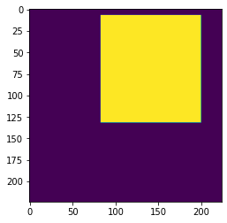

```python
#### Add your code here ####
plt.imshow(y_test[6])
```

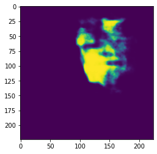

```python
plt.imshow(y_pred[6])
```

### Impose the mask on the test image (3 marks)

- In imshow use the alpha parameter and set it to greater than 0.5

```
Clipping input data to the valid range for imshow with RGB data ([0..1] for floats or [0..255] for integers).
```

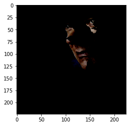

```python
#### Add your code here ####
pred_mask = cv2.resize(1.0*(y_pred[6] > 0.5), (IMAGE_WIDTH,IMAGE_HEIGHT))

image = X_test[6]
image2 = image
image2[:,:,0] = pred_mask*image[:,:,0]
image2[:,:,1] = pred_mask*image[:,:,1]
image2[:,:,2] = pred_mask*image[:,:,2]

out_image = image2

plt.imshow(out_image)
```

# Closing remarks